# ST310 Group Project

2024-03-04

# Wine Quality Prediction

In this group project, we aim to answer the question of what is the best model to predict the quality of white wine based on its physicochemical properties, and to what extent can we predict red wine quality with models trained on white wine data.

## Dataset Description

This dataset contains physicochemical and sensory data for red wine and white wine. It contains 11 input variables capturing wine properties like acidity, sugar, alcohol levels, etc. The output variable is a wine quality score between 3 and 9 as rated. The red wine dataset has 1,599 instances, while the white wine dataset is larger with 4,898 instances.

```r
wine.red <- read.csv("winequality-red.csv", header = T, sep = ';')
wine.white <- read.csv("winequality-white.csv", header = T, sep = ';')
predictors <- setdiff(names(wine.white), "quality")
names(wine.white)
```

```
##  [1] "fixed.acidity"        "volatile.acidity"     "citric.acid"
##  [4] "residual.sugar"       "chlorides"            "free.sulfur.dioxide"
##  [7] "total.sulfur.dioxide" "density"              "pH"
## [10] "sulphates"            "alcohol"              "quality"
```

```r
dim(wine.red)
```

```
## [1] 1599   12
```

```r
dim(wine.white)
```

```
## [1] 4898   12
```

## Introduction

We used the dataset of white wine to fit various regression models, high-dimensional models, gradient descent, and other techniques for training purposes. Additionally, we utilised the dataset of red wine for OOD generalization to compare the RMSE and MAE of the trained models on this unseen OOD dataset with the corresponding metrics from the training and testing sets.

## Exploratory Data Analysis

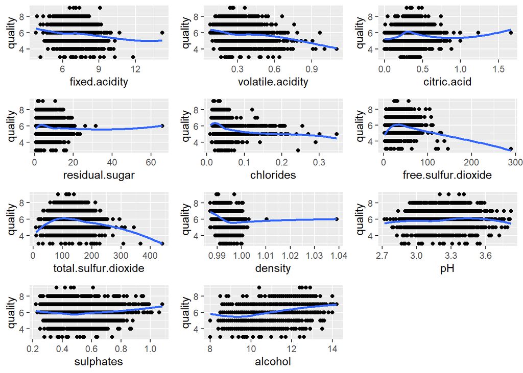

```r
# Generating plots with a loop
plot_list <- list()
for(predictor in predictors) {
  p <- ggplot(wine.white, aes(x = !!sym(predictor), y = quality)) +
    geom_point() +
    geom_smooth(method = "loess", se = FALSE)
    ggtitle(paste("Q vs", predictor)) +
    theme(legend.position = "none")
  plot_list[[predictor]] <- p
}
do.call(grid.arrange, c(plot_list, ncol = 3))
```

#### Preparing Dataset

Firstly, We splited the white wine dataset into training (70%) and testing (30%) sets for model training.Then we created a recipe to normalize numeric predictors and preprocessed the data. Furthermore, we set up 5-fold cross-validation for hyperparameter tuning. Lastly, we defined custom functions and initialised a tibble to store combined results.

```r
# Splitting the datset into 70% and 30%
split.white <- initial_split(wine.white, prop = 0.7)
train.white <- training(split.white)
test.white <- testing(split.white)

# Create the recipe and preprocess the data
recipe.white <- recipe(quality ~ ., data = train.white) |>
  step_normalize(all_numeric_predictors())

prep.white <- prep(recipe.white)
bake.white.train <- juice(prep.white)
bake.white.test <- bake(prep.white, test.white)
bake.red <- bake(prep.white, wine.red)

# Define a cross-validation and global variables
resamples <- vfold_cv(train.white, v = 5)
iter = 5
reci <- recipe.white
data_train <- train.white
data_test <- test.white

# Create a workflow
wf_custom <- function(model) {
  workflow() |>
    add_recipe(reci) |>
    add_model(model)
}

# Perform hyperparameter tuning
grid_custom <- function(wf, grid = 100) {
  wf |>
    tune_grid(
      resamples = resamples,
      grid = grid,
      metrics = metric_set(rmse),
      control = control_grid(parallel_over = "everything", verbose = FALSE)
    )
}

# Fit a model with the best hyperparameters
fit_custom <- function(wf, tuned_results) {
  wf |>
    finalize_workflow(select_best(tuned_results, metric = "rmse")) |>
    fit(data = data_train)
}

# Evaluate a fitted model on both training and testing data
eval_test_custom <- function(fitted_model, model_name) {
  test_preds <- predict(fitted_model, new_data = data_test) |>
    bind_cols(actual = data_test$quality)
  train_preds <- predict(fitted_model, new_data = data_train) |>
    bind_cols(actual = data_train$quality)
  rmse_tra <- rmse(train_preds, truth = actual, estimate = .pred) |> pull(.estimate)
  mae_tra <- mae(train_preds, truth = actual, estimate = .pred) |> pull(.estimate)
  rmse_val <- rmse(test_preds, truth = actual, estimate = .pred) |> pull(.estimate)
  mae_val <- mae(test_preds, truth = actual, estimate = .pred) |> pull(.estimate)
  tibble(
    model = model_name,
    test_rmse = rmse_val,
    test_mae = mae_val,
    train_rmse = rmse_tra,
    train_mae = mae_tra
  )
}
# Initilise results tibble
results_combined <- tibble(model = character(), test_rmse = numeric(),
                           test_mae = numeric(), train_rmse = numeric(), train_mae = numeric())
```

```r
# Load tuned results as tuning is very time-consuming during knitting
load("high_dim_data.RData")
load("data.RData")
```

## Model Fitting and Evaluation

### Baseline Linear Regression Model

The baseline model is a simple linear regression model that is used as a benchmark for comparison with more sophisticated models. In this case, we only considered three plausible predictors through looking at plots (`alcohol`, `PH` and `residual sugar`) and assumes a linear relationship between these predictors and the target variable.

```r
baseline_lm <- linear_reg() |> set_engine("lm") |> set_mode("regression")
lm_baseline_fitted <- baseline_lm |> fit(formula = quality~alcohol+pH+residual.sugar, data = train.white)
lm_baseline_results <- eval_test_custom(lm_baseline_fitted, "lm_baseline")
results_combined <- bind_rows(results_combined, lm_baseline_results)
lm_baseline_results
```

```
## # A tibble: 1 × 5
##   model       test_rmse test_mae train_rmse train_mae
##   <chr>           <dbl>    <dbl>      <dbl>     <dbl>
## 1 lm_baseline     0.774    0.609      0.795     0.624
```

### Baseline Multiple Minear Regression Model

We fitted a standard linear regression model as a baseline, considering all possible predictors to capture potential relationships with wine quality. This standard model assumes a linear relationship between the properties and the target variable. Also, it showed improved predictive accuracy over the previous one.

```r
lm_model <- linear_reg() |> set_engine("lm") |> set_mode("regression")
wf_lm <- wf_custom(lm_model)
lm_fitted <- wf_lm |> fit(data = train.white)
lm_results <- eval_test_custom(lm_fitted, "lm")
results_combined <- bind_rows(results_combined, lm_results)
lm_results
```

```
## # A tibble: 1 × 5
##   model test_rmse test_mae train_rmse train_mae
##   <chr>     <dbl>    <dbl>      <dbl>     <dbl>
## 1 lm        0.742    0.578      0.755     0.587
```

## None-baseline Models

### Random Forest Model

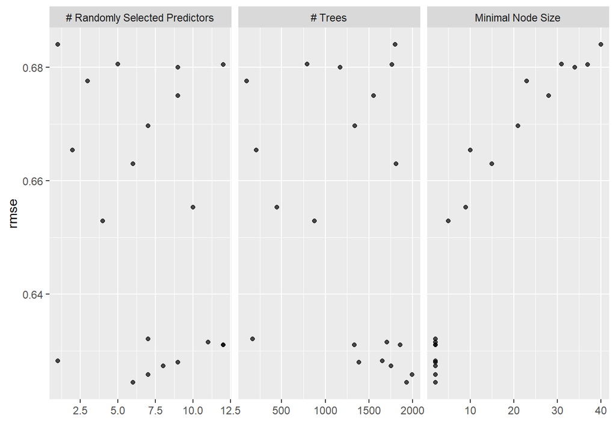

```r
rf_spec <-
  rand_forest(
    mtry = tune(),
    trees = tune(),
    min_n = tune()
  ) |>
  set_engine("ranger") |>
  set_mode("regression")
rf_wf <- wf_custom(rf_spec)
rf_set <- rf_wf |> extract_parameter_set_dials() |>
  update(mtry = finalize(mtry(), data_train))
# rf_tuned <- rf_wf |> tune_bayes(
#   resamples = resamples,
#   initial = 10,
#   iter = 10,
#   metrics = metric_set(rmse),
#   param_info = rf_set,
#   control = control_bayes(no_improve = 5, verbose = F)
# )
autoplot(rf_tuned)
```

```r
show_best(rf_tuned, metric = "rmse", n = 5)
```

```
## # A tibble: 5 × 10
##    mtry trees min_n .metric .estimator  mean     n std_err .config .iter
##   <int> <int> <int> <chr>   <chr>      <dbl> <int>   <dbl> <chr>   <int>
## 1     6  1935     2 rmse    standard   0.624     5  0.0106 Iter9       9
## 2     7  1995     2 rmse    standard   0.626     5  0.0110 Iter6       6
## 3     8  1756     2 rmse    standard   0.627     5  0.0109 Iter5       5
## 4     9  1384     2 rmse    standard   0.628     5  0.0111 Iter4       4
## 5     1  1654     2 rmse    standard   0.628     5  0.0102 Iter10     10
```

```r
rf_fitted <- fit_custom(rf_wf, rf_tuned)
(rf_results <- eval_test_custom(rf_fitted, "rf"))
```

```
## # A tibble: 1 × 5
##   model test_rmse test_mae train_rmse train_mae
##   <chr>     <dbl>    <dbl>      <dbl>     <dbl>
## 1 rf        0.597    0.435      0.236     0.169
```

```r
results_combined <- bind_rows(results_combined, rf_results)
```

### Boosted Tree Model

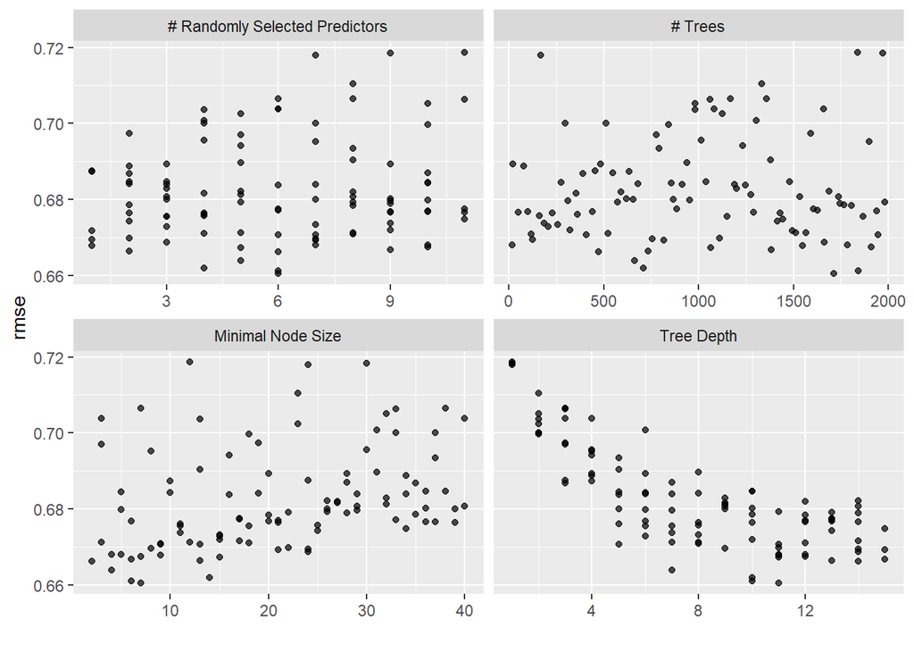

```r
boost_spec <- boost_tree(trees = tune(), tree_depth = tune(), mtry = tune(), min_n = tune()) |>
  set_engine("xgboost", nthread = 16) |>
  set_mode("regression")
boost_wf <- wf_custom(boost_spec)
# boost_tuned <- grid_custom(boost_wf, grid = 30)
autoplot(boost_tuned)
```

```r
boost_fitted <- fit_custom(boost_wf, boost_tuned)
boost_results <- eval_test_custom(boost_fitted, "boost")
results_combined <- bind_rows(results_combined, boost_results)
boost_results
```

```
## # A tibble: 1 × 5
##   model test_rmse test_mae train_rmse train_mae
##   <chr>     <dbl>    <dbl>      <dbl>     <dbl>
## 1 boost     0.645    0.425    0.00155  0.000791
```

### Single Tree Mode

For singe tree model, we tuned three hyperparameters: `tree_depth`, `min_n` and `cost_complexity`.The first plot suggests an optimal cost_complexity around -5 to -2.5 on the log-10 scale. The second plot indicates an optimal min_n of 10 to 20 observations per leaf node. The third plot shows an optimal tree_depth of 4 to 8 levels, balancing underfitting and overfitting. After tuning, the single tree model achieved an RMSE of 0.74 on the test set, relatively lower than the baseline simple linear regression model, but significantly more complex. It can be concluded that the model is not a great choice for predicting wine quality.

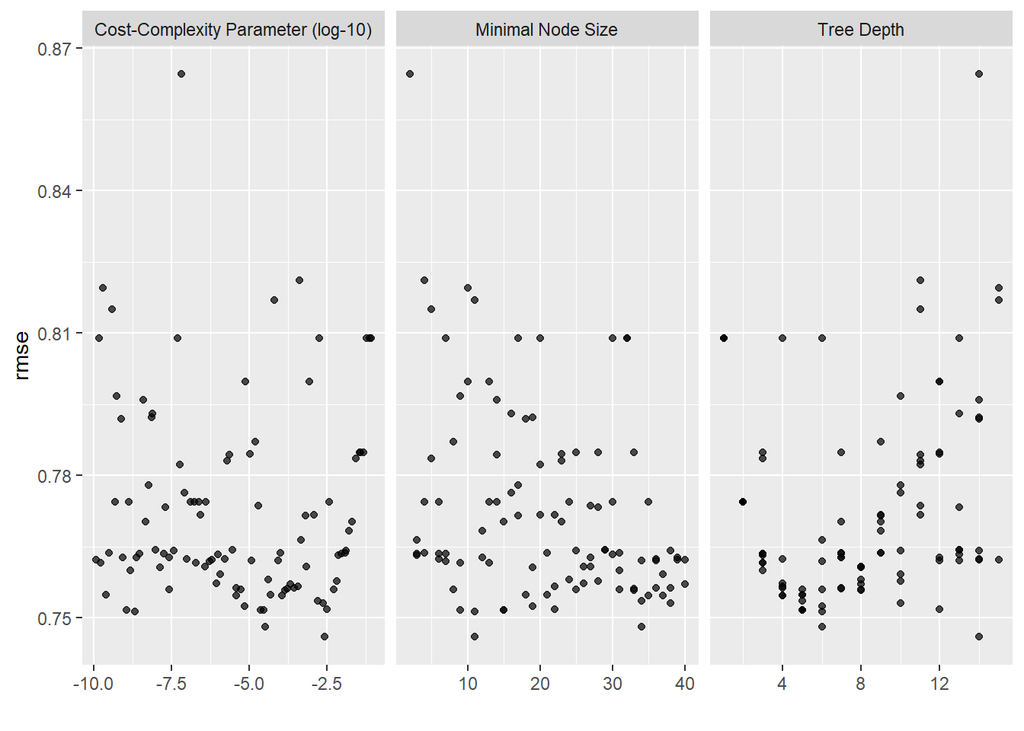

```r
tree_spec <- decision_tree(tree_depth = tune(), min_n = tune(), cost_complexity = tune()) |>
  set_engine("rpart") |>
  set_mode("regression")
tree_wf <- wf_custom(tree_spec)
# tree_tuned <- grid_custom(tree_wf)
autoplot(tree_tuned)
```

```r
tree_fitted <- fit_custom(tree_wf, tree_tuned)
tree_results <- eval_test_custom(tree_fitted, "tree")
results_combined <- bind_rows(results_combined, tree_results)
tree_results
```

```
## # A tibble: 1 × 5
##   model test_rmse test_mae train_rmse train_mae
##   <chr>     <dbl>    <dbl>      <dbl>     <dbl>
## 1 tree      0.742    0.582      0.674     0.529
```

### Cubist Model

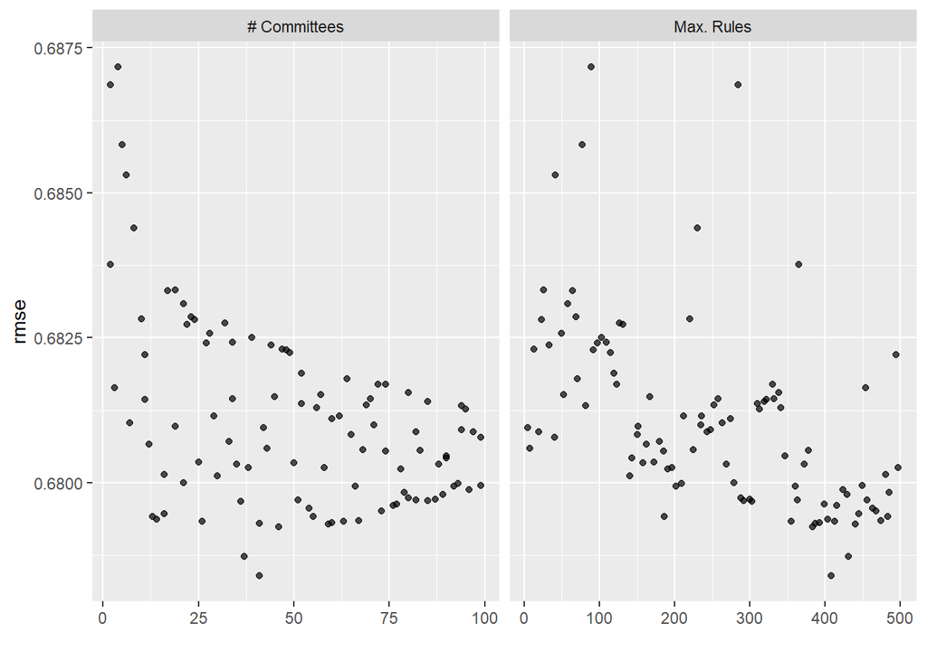

```r
cubist_spec <- cubist_rules(committees = tune(), neighbors = 5, max_rules = tune(), engine = "Cubist") |>
  set_mode("regression")
cubist_wf <- wf_custom(cubist_spec)
# cubist_tuned <- grid_custom(cubist_wf)
autoplot(cubist_tuned)
```

```r
cubist_fitted <- fit_custom(cubist_wf, cubist_tuned)
cubist_results <- eval_test_custom(cubist_fitted, "cubist")
results_combined <- bind_rows(results_combined, cubist_results)
cubist_results
```

```
## # A tibble: 1 × 5
##   model  test_rmse test_mae train_rmse train_mae
##   <chr>      <dbl>    <dbl>      <dbl>     <dbl>
## 1 cubist     0.660    0.493      0.415     0.307
```

### Elastic Net Model

The elastic net model is a linear regression model that incorporates lasso and ridge regularization. The tuned hyperparameters included the penalty factor and the mixture ratio between lasso and ridge penalties. After tuning, the elastic net model achieved an RMSE of 0.74 on the test set. The tuned elastic net model has an alpha value close to 1, meaning the end result is similar to lasso regression. Additionally, because the best penalty is very small, it indicates that the tuned model is effectively a simple linear regression with all predictors included.

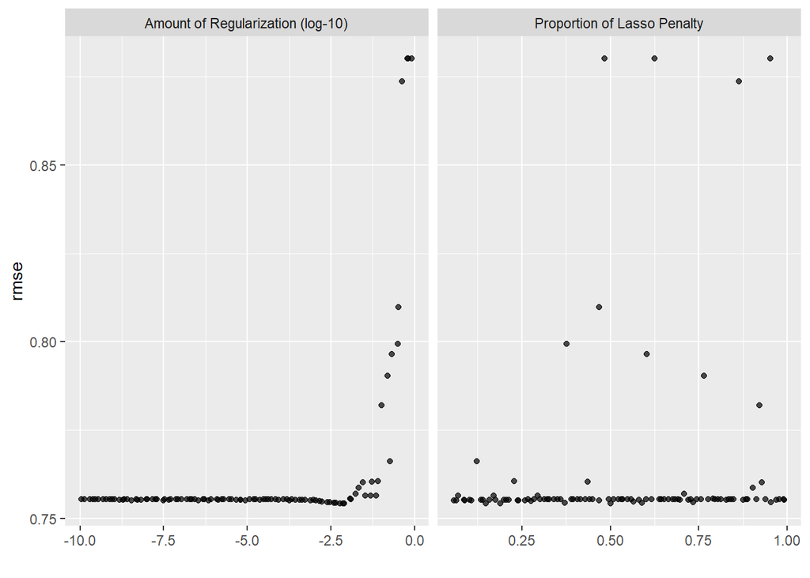

```r
enet_spec <- linear_reg(penalty = tune(), mixture = tune()) |>
  set_engine("glmnet") |>
  set_mode("regression")
enet_wf <- wf_custom(enet_spec)
# enet_tuned <- grid_custom(enet_wf)
autoplot(enet_tuned)
```

```r
enet_fitted <- fit_custom(enet_wf, enet_tuned)
enet_results <- eval_test_custom(enet_fitted, "enet")
results_combined <- bind_rows(results_combined, enet_results)
enet_results
```

```
## # A tibble: 1 × 5
##   model test_rmse test_mae train_rmse train_mae
##   <chr>     <dbl>    <dbl>      <dbl>     <dbl>
## 1 enet      0.743    0.579      0.755     0.588
```

### Support Vector Machine Model

The SVM model is also a non-baseline model. The tuned hyperparameters included the cost parameter, the RBF kernel parameter (sigma), and the insensitivity margin. The plots show the relationship between these hyperparameters and the RMSE, but no clear relationship can be witnessed. After tuning, the SVM model achieved an RMSE of 0.70 on the test set.

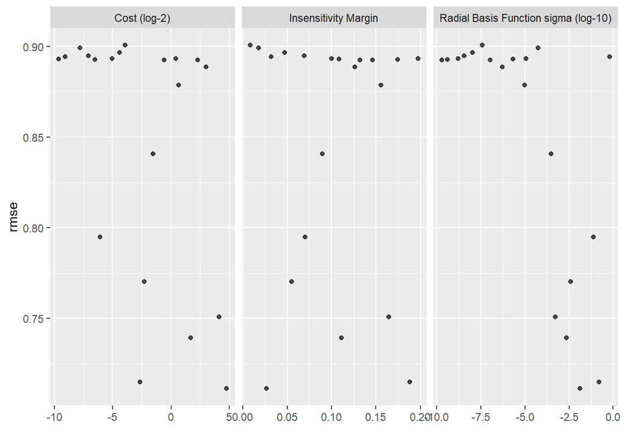

```r
svm_spec <- svm_rbf(mode = "regression", engine = "kernlab", cost = tune(), rbf_sigma = tune(), margin = tune())
svm_wf <- wf_custom(svm_spec)
svm_tuned <- grid_custom(svm_wf, grid = 20)
autoplot(svm_tuned)
```

```r
show_best(svm_tuned, metric = "rmse", n = 10)
```

```
## # A tibble: 10 × 9
##       cost   rbf_sigma margin .metric .estimator  mean     n std_err .config
##      <dbl>       <dbl>  <dbl> <chr>   <chr>      <dbl> <int>   <dbl> <chr>
##  1 27.0    0.0129      0.0268 rmse    standard   0.711     5 0.00355 Preprocess…
##  2  0.159  0.154       0.188  rmse    standard   0.715     5 0.00489 Preprocess…
##  3  3.20   0.00227     0.111  rmse    standard   0.739     5 0.00771 Preprocess…
##  4 17.4    0.000517    0.165  rmse    standard   0.751     5 0.00806 Preprocess…
##  5  0.200  0.00380     0.0547 rmse    standard   0.770     5 0.00759 Preprocess…
##  6  0.0147 0.0761      0.0701 rmse    standard   0.795     5 0.00620 Preprocess…
##  7  0.342  0.000303    0.0895 rmse    standard   0.841     5 0.00636 Preprocess…
##  8  1.57   0.00000939  0.156  rmse    standard   0.879     5 0.00560 Preprocess…
##  9  7.96   0.000000536 0.126  rmse    standard   0.889     5 0.00559 Preprocess…
## 10  0.666  0.000000108 0.132  rmse    standard   0.892     5 0.00559 Preprocess…
```

```r
svm_fitted <- fit_custom(svm_wf, svm_tuned)
svm_results <- eval_test_custom(svm_fitted, "svm")
results_combined <- bind_rows(results_combined, svm_results)
svm_results
```

```
## # A tibble: 1 × 5
##   model test_rmse test_mae train_rmse train_mae
##   <chr>     <dbl>    <dbl>      <dbl>     <dbl>
## 1 svm       0.702    0.539      0.672     0.497
```

### Neural Network with Single Hidden Layer

Normally the number of hidden units should not exceed twice the length of input vector, but for this dataset an increased number of hidden units does not lead to significant overfitting, suggesting that the model benefits from the higher capacity to capture complex patterns. The MLP model may have limitations in capturing feature interactions and may require further hyperparameter tuning to improve its performance. Tuning dropout rate does not meaningfully improve the model’s performance, also suggesting that the model may not be overfitting.

```r
mlp_spec <- mlp(mode = "regression", engine = "keras", hidden_units = 64, dropout = 0.2, epochs = 80)
mlp_wf <- wf_custom(mlp_spec)
```

Unable to suppress the following output

[output not shown]

[output cut: 25 more lines]

[output not shown]

```r
mlp_results <- eval_test_custom(mlp_fitted, "mlp")
```

```
## 46/46 - 0s - 83ms/epoch - 2ms/step
## 108/108 - 0s - 82ms/epoch - 760us/step
```

```r
results_combined <- bind_rows(results_combined, mlp_results)
```

### Lasso Model

For lasso regression model, we tuned the hyperparameter of penalty factor, which controls the amount of regularization. The plot shows the relationship between the amount of regularization and the RMSE, indicating that a moderate amount of regularization is optimal. After tuning, the lasso regression model achieved an RMSE of 0.74 on the test set, which is very close to the RMSE obtained by the elastic net model. This similarity can be attributed to the fact that the elastic net model, with its tuned hyperparameters, effectively reduced to a lasso-like solution.

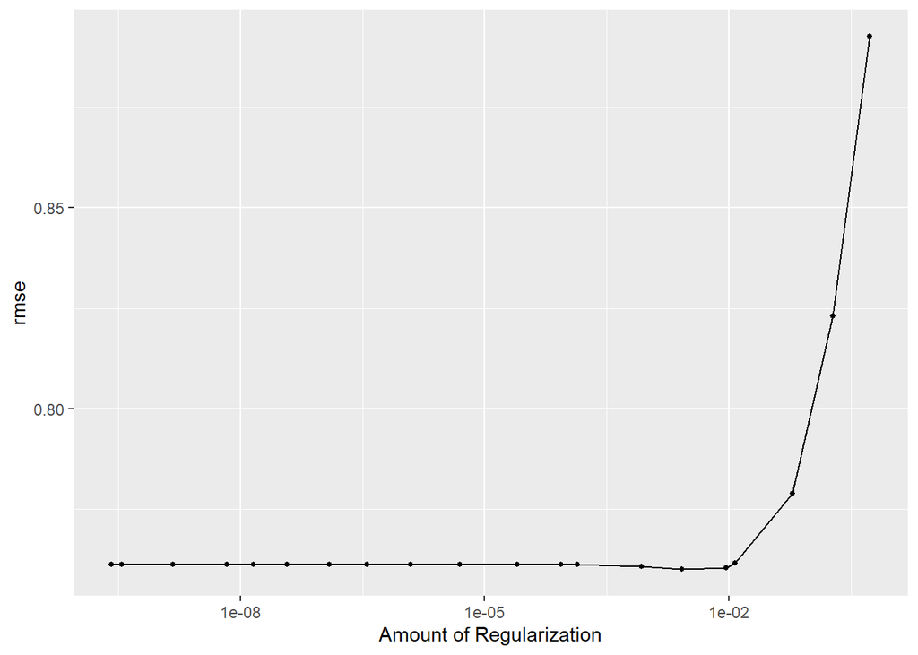

```r
# Lasso regression model
lasso_spec <- linear_reg(penalty = tune(), mixture = 1) |> set_engine("glmnet") |> set_mode("regression")
lasso_wf <- wf_custom(lasso_spec)
lasso_tuned <- grid_custom(lasso_wf, grid = 20)
autoplot(lasso_tuned)
```

```r
show_best(lasso_tuned, metric = "rmse", n = 10)
```

```
## # A tibble: 10 × 7
##     penalty .metric .estimator  mean     n std_err .config
##       <dbl> <chr>   <chr>      <dbl> <int>   <dbl> <chr>
##  1 2.62e- 3 rmse    standard   0.760     5 0.00711 Preprocessor1_Model15
##  2 9.26e- 3 rmse    standard   0.760     5 0.00627 Preprocessor1_Model16
##  3 8.38e- 4 rmse    standard   0.761     5 0.00796 Preprocessor1_Model14
##  4 2.63e-10 rmse    standard   0.761     5 0.00830 Preprocessor1_Model01
##  5 3.51e-10 rmse    standard   0.761     5 0.00830 Preprocessor1_Model02
##  6 1.49e- 9 rmse    standard   0.761     5 0.00830 Preprocessor1_Model03
##  7 6.79e- 9 rmse    standard   0.761     5 0.00830 Preprocessor1_Model04
##  8 1.46e- 8 rmse    standard   0.761     5 0.00830 Preprocessor1_Model05
##  9 3.72e- 8 rmse    standard   0.761     5 0.00830 Preprocessor1_Model06
## 10 1.25e- 7 rmse    standard   0.761     5 0.00830 Preprocessor1_Model07
```

```r
lasso_fitted <- fit_custom(lasso_wf, lasso_tuned)
lasso_fitted |> pull_workflow_fit() |> tidy()
```

```
## # A tibble: 12 × 3
##    term                 estimate penalty
##    <chr>                   <dbl>   <dbl>
##  1 (Intercept)            5.87   0.00262
##  2 fixed.acidity          0.0109 0.00262
##  3 volatile.acidity      -0.199  0.00262
##  4 citric.acid            0.0134 0.00262
##  5 residual.sugar         0.339  0.00262
##  6 chlorides             -0.0141 0.00262
##  7 free.sulfur.dioxide    0.0471 0.00262
##  8 total.sulfur.dioxide   0      0.00262
##  9 density               -0.335  0.00262
## 10 pH                     0.0646 0.00262
## 11 sulphates              0.0602 0.00262
## 12 alcohol                0.298  0.00262
```

```r
lasso_results <- eval_test_custom(lasso_fitted, "lasso")
results_combined <- bind_rows(results_combined, lasso_results)
lasso_results
```

```
## # A tibble: 1 × 5
##   model test_rmse test_mae train_rmse train_mae
##   <chr>     <dbl>    <dbl>      <dbl>     <dbl>
## 1 lasso     0.742    0.579      0.755     0.588
```

### Generalized Additive Model

GAM is relatively interpretable and can capture non-linear relationships between predictors and the target variable. It is a good choice for this dataset because it has a relative small number of predictors and the relationship between predictors and the target variable is not linear.

```r
# .742
names(bake.white.train)
```

```
##  [1] "fixed.acidity"        "volatile.acidity"     "citric.acid"
##  [4] "residual.sugar"       "chlorides"            "free.sulfur.dioxide"
##  [7] "total.sulfur.dioxide" "density"              "pH"
## [10] "sulphates"            "alcohol"              "quality"
```

```r
gam_fitted <- gam::gam(quality ~ .+ ns(residual.sugar, 2) + s(citric.acid, 2)+
                         s(alcohol,2) + s(chlorides, 2) , data=bake.white.train)
# .746
gam_fitted <- gam::gam(quality ~ .+ ns(residual.sugar, 2) + s(citric.acid, 2)
                      , data=bake.white.train)
# .740
gam_fitted <- gam::gam(quality ~ .+ ns(residual.sugar, 2) + s(citric.acid, 2)+
        ns(fixed.acidity,2)+s(alcohol,2) + s(chlorides, 2) , data=bake.white.train)
# .740
gam_fitted <- gam::gam(quality ~ .+ ns(residual.sugar, 2) + s(citric.acid, 2)+
    ns(fixed.acidity,2)+s(alcohol,2) + s(chlorides, 2) , data=bake.white.train)
# 0.720
gam_fitted <- gam::gam(quality ~
                         s(volatile.acidity) +
                         s(citric.acid) +
                         residual.sugar +
                         s(chlorides) +
                         s(total.sulfur.dioxide) +
                         free.sulfur.dioxide +
                         density +
                         s(pH) +
                         s(sulphates) +
                         s(alcohol),
                       data = bake.white.train)

# Calculate the RMSE and MAE for training set and test set gam_fitted
gam_train_pred <- predict(gam_fitted, bake.white.train)
gam_test_pred <- predict(gam_fitted, bake.white.test)
gam_train_rmse <- sqrt(mean((gam_train_pred - bake.white.train$quality)^2))
gam_test_rmse <- sqrt(mean((gam_test_pred - bake.white.test$quality)^2))
gam_train_mae <- mean(abs(gam_train_pred - bake.white.train$quality))
gam_test_mae <- mean(abs(gam_test_pred - bake.white.test$quality))
gam_results <- tibble(
  model = "gam",
  train_rmse = gam_train_rmse,
  test_rmse = gam_test_rmse,
  train_mae = gam_train_mae,
  test_mae = gam_test_mae
)
gam_results
```

```
## # A tibble: 1 × 5
##   model train_rmse test_rmse train_mae test_mae
##   <chr>      <dbl>     <dbl>     <dbl>    <dbl>
## 1 gam        0.725     0.725     0.568    0.565
```

```r
(results_combined <- bind_rows(results_combined, gam_results))
```

```
## # A tibble: 22 × 5
##    model  test_rmse test_mae train_rmse train_mae
##    <chr>      <dbl>    <dbl>      <dbl>     <dbl>
##  1 rf         0.609    0.446    0.233    0.166
##  2 boost      0.653    0.432    0.00180  0.000975
##  3 cubist     0.656    0.493    0.422    0.311
##  4 svm        0.674    0.486    0.149    0.144
##  5 gam        0.729    0.579    0.724    0.565
##  6 mlp        0.737    0.584    0.722    0.574
##  7 tree       0.740    0.582    0.689    0.541
##  8 enet       0.749    0.589    0.752    0.583
##  9 lasso      0.754    0.591    0.751    0.582
## 10 lm         0.755    0.587    0.749    0.583
## # ℹ 12 more rows
```

The selection of splines and their degrees of freedom are chosen based on the plots for each predictor against quality. Several models are fitted with different combinations of splines and degrees of freedom. The best model is the one with the most non-linear terms, but the model’s train-test RMSE gap is still very small. This is a sign of potential underfitting.

```r
# Delete duplicated rows by model name in results_combined
results_combined <- results_combined[!duplicated(results_combined$model),]
#  Store results by test_rmse
results_combined <- results_combined[order(results_combined$test_rmse),]
save(rf_tuned,
     lm_fitted,
     tree_tuned,
     boost_tuned,
     cubist_tuned,
     enet_tuned,
     svm_tuned,
     gam_fitted,
     results_combined,
     file = "data.RData")
results_combined
```

```
## # A tibble: 11 × 5
##    model       test_rmse test_mae train_rmse train_mae
##    <chr>           <dbl>    <dbl>      <dbl>     <dbl>
##  1 rf              0.609    0.446    0.233    0.166
##  2 boost           0.653    0.432    0.00180  0.000975
##  3 cubist          0.656    0.493    0.422    0.311
##  4 svm             0.674    0.486    0.149    0.144
##  5 gam             0.729    0.579    0.724    0.565
##  6 mlp             0.737    0.584    0.722    0.574
##  7 tree            0.740    0.582    0.689    0.541
##  8 enet            0.749    0.589    0.752    0.583
##  9 lasso           0.754    0.591    0.751    0.582
## 10 lm              0.755    0.587    0.749    0.583
## 11 lm_baseline     0.785    0.621    0.791    0.618
```

### Comment on the results table

- Baseline Models: Two Linear Regression models, one with all predictors and the other with three predictors
- Non-baseline models but still relatively interpretable: GAM, Lasso, and Elastic Net. Single Tree is more interpretable than other tree models, but still less interpretable than the three models mentioned above. GAM is the best among thses on in-distribution test data. Notably, Elastic Net and its special variant lasso are all close to Linear Regression after tuning.
- Models focused on predictive accuracy without interpretability: Random Forest, Boosted Trees, Cubist, SVM, and Neural Network (the least interpretable one) with one hidden layer. Random Forest performs the best among these.  
  High Dimensional Models and our own implementation of gradient descent are included below.

## High Dimensional Models

In this section, the high-dimensional dataset with 111 columns is prepared. The original dataset undergoes several transformations and mutations to create new features. The mutate() function is used to apply polynomial transformations (squared, cubic, quartic, and log) to each predictor.  
Additionally, interaction terms are created by combining pairs of predictors using the combn() function. These interaction terms capture the joint effect of two predictors on the target variable.  
Principal Component Analysis is used to reduce the dimensionality of the dataset. The step_pca() function is used within the recipe to perform PCA on all predictors, with a threshold of 0.95. This means that PCA selects the principal components that explain 95% of the total variance in the dataset. 51 Predictors are selected by PCA.

```r
## Prepare the high dimensional dataset
# Extend the dataset with polynomial (squared, cubic, quartic, log) transformations
wine_data <- bake(prep.white, wine.white)
predictors <- setdiff(names(wine_data), "quality")
wine_data_extended <- wine_data |>
  mutate(across(all_of(predictors), ~ .^2, .names = "{.col}_squared")) |>
  mutate(across(all_of(predictors), ~ .^3, .names = "{.col}_cubic")) |>
  mutate(across(all_of(predictors), ~ .^4, .names = "{.col}_quartic")) |>
  mutate(across(all_of(predictors), ~ log(. + 4), .names = "{.col}_log"))

# Add interaction terms between predictors
combinations <- combn(predictors, 2, simplify = FALSE)
for(combo in combinations) {
  wine_data_extended[[paste(combo, collapse = "X")]] <- wine_data[[combo[1]]] * wine_data[[combo[2]]]
}
wine_data_extended <- data.frame(wine_data_extended)

# Split the dataset
split_hd <- initial_split(wine_data_extended, prop = 0.7)
data_train <- training(split_hd)
data_test <- testing(split_hd)
resamples <- vfold_cv(data_train, v = 5)

# Normalize predictors
reci_hd <- recipe(quality ~ ., data = data_train) |> step_normalize(all_predictors())
reci_pca <- recipe(quality ~ ., data = data_train) |> step_normalize(all_predictors()) |> step_pca(all_predictors(), threshold = 0.95)

# Get number of predictors selected by PCA out of 110 in total
num_predictors <- dim(juice(reci_pca |> prep()))[2]

# Use Lasso and SVM models
lasso_spec <- linear_reg(penalty = tune(), mixture = 1) |> set_engine("glmnet")
svm_spec <- svm_rbf(mode = "regression", engine = "kernlab", cost = tune(), rbf_sigma = tune(), margin = tune())

# Create workflows for Lasso and SVM with and without PCA
lasso_hd_wf <- workflow() |> add_model(lasso_spec) |> add_recipe(reci_hd)
lasso_pca_wf <- workflow() |> add_model(lasso_spec) |> add_recipe(reci_pca)
svm_hd_wf <- workflow() |> add_model(svm_spec) |> add_recipe(reci_hd)
svm_pca_wf <- workflow() |> add_model(svm_spec) |> add_recipe(reci_pca)
```

Two models, Lasso and Support Vector Machine, are used for high-dimensional modeling.

### Tune and evaluate SVM models

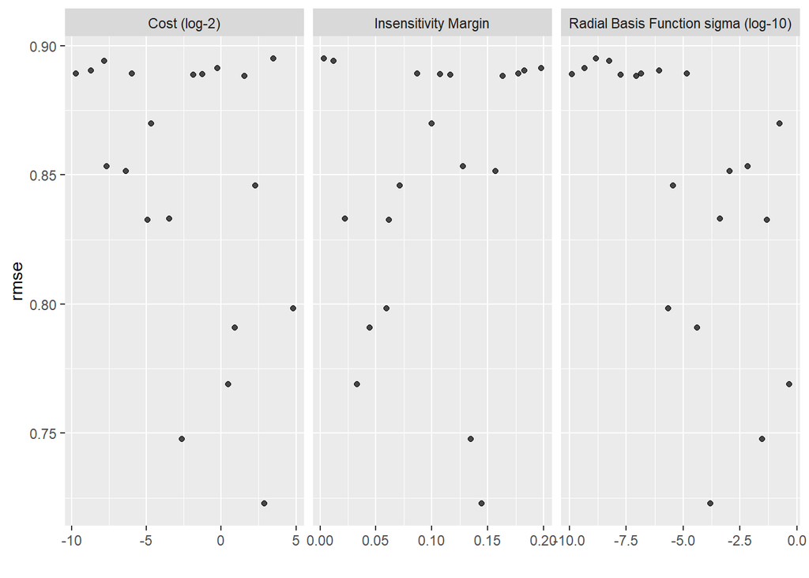

```r
svm_tuned_hd <- grid_custom(svm_hd_wf, grid = 20)
svm_tuned_pca <- grid_custom(svm_pca_wf, grid = 20)
autoplot(svm_tuned_hd)
```

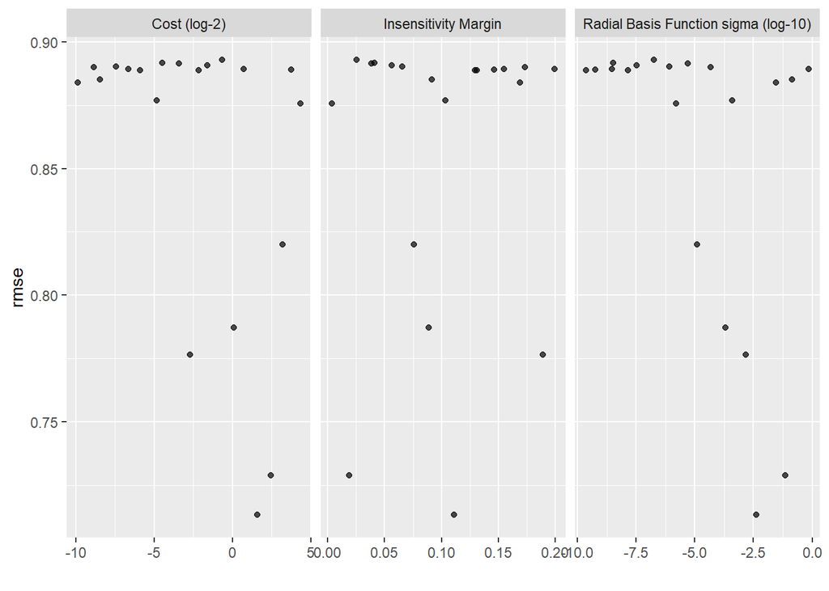

```r
autoplot(svm_tuned_pca)
```

```r
show_best(svm_tuned_hd, metric = "rmse", n = 5)
```

```
## # A tibble: 5 × 9
##     cost  rbf_sigma margin .metric .estimator  mean     n std_err .config
##    <dbl>      <dbl>  <dbl> <chr>   <chr>      <dbl> <int>   <dbl> <chr>
## 1  7.31  0.000158   0.145  rmse    standard   0.723     5 0.00547 Preprocessor1…
## 2  0.161 0.0289     0.135  rmse    standard   0.748     5 0.00766 Preprocessor1…
## 3  1.37  0.457      0.0332 rmse    standard   0.769     5 0.00806 Preprocessor1…
## 4  1.86  0.0000420  0.0445 rmse    standard   0.791     5 0.00622 Preprocessor1…
## 5 28.1   0.00000215 0.0595 rmse    standard   0.798     5 0.00629 Preprocessor1…
```

```r
show_best(svm_tuned_pca, metric = "rmse", n = 5)
```

```
## # A tibble: 5 × 9
##    cost rbf_sigma margin .metric .estimator  mean     n std_err .config
##   <dbl>     <dbl>  <dbl> <chr>   <chr>      <dbl> <int>   <dbl> <chr>
## 1 3.00  0.00423   0.111  rmse    standard   0.713     5 0.00573 Preprocessor1_M…
## 2 5.51  0.0722    0.0187 rmse    standard   0.729     5 0.00975 Preprocessor1_M…
## 3 0.151 0.00150   0.189  rmse    standard   0.776     5 0.00468 Preprocessor1_M…
## 4 1.06  0.000206  0.0891 rmse    standard   0.787     5 0.00679 Preprocessor1_M…
## 5 9.20  0.0000126 0.0760 rmse    standard   0.820     5 0.00798 Preprocessor1_M…
```

```r
svm_hd_fitted <- fit_custom(svm_hd_wf, svm_tuned_hd)
svm_pca_fitted <- fit_custom(svm_pca_wf, svm_tuned_pca)
svm_hd_results <- eval_test_custom(svm_hd_fitted, "svm_hd")
svm_pca_results <- eval_test_custom(svm_pca_fitted, "svm_with_pca")
```

### Tune and evaluate Lasso models

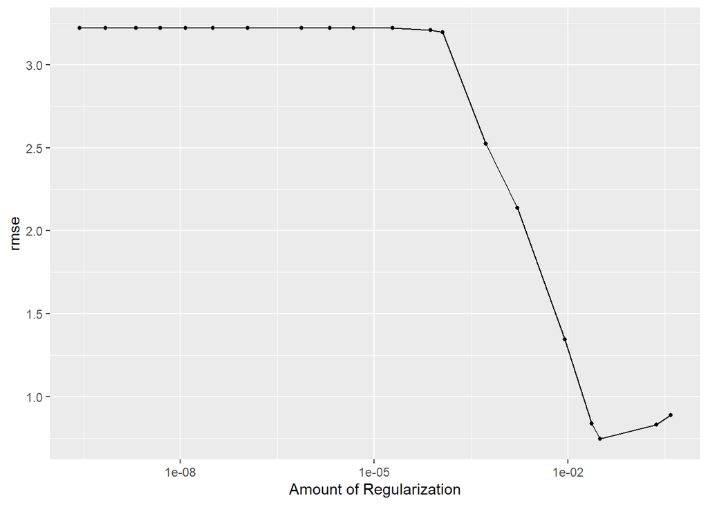

```r
lasso_tuned_hd <- grid_custom(lasso_hd_wf, grid = 20)
lasso_tuned_pca <- grid_custom(lasso_pca_wf, grid = 20)
autoplot(lasso_tuned_hd)
```

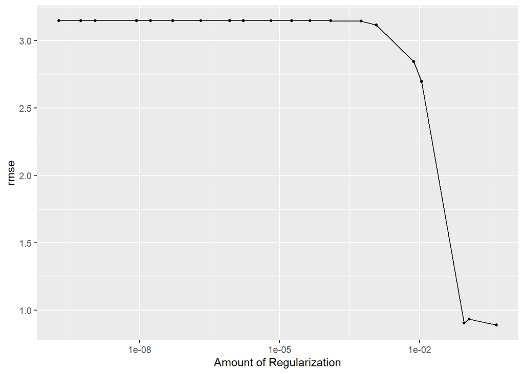

```r
autoplot(lasso_tuned_pca)
```

```r
show_best(lasso_tuned_hd, metric = "rmse", n = 5)
```

```
## # A tibble: 5 × 7
##   penalty .metric .estimator  mean     n std_err .config
##     <dbl> <chr>   <chr>      <dbl> <int>   <dbl> <chr>
## 1 0.0318  rmse    standard   0.744     5 0.00544 Preprocessor1_Model18
## 2 0.234   rmse    standard   0.833     5 0.00420 Preprocessor1_Model19
## 3 0.0234  rmse    standard   0.836     5 0.0942  Preprocessor1_Model17
## 4 0.389   rmse    standard   0.888     5 0.00535 Preprocessor1_Model20
## 5 0.00901 rmse    standard   1.34      5 0.580   Preprocessor1_Model16
```

```r
show_best(lasso_tuned_pca, metric = "rmse", n = 5)
```

```
## # A tibble: 5 × 7
##   penalty .metric .estimator  mean     n std_err .config
##     <dbl> <chr>   <chr>      <dbl> <int>   <dbl> <chr>
## 1 0.437   rmse    standard   0.889     5 0.00487 Preprocessor1_Model20
## 2 0.0891  rmse    standard   0.904     5 0.0543  Preprocessor1_Model18
## 3 0.114   rmse    standard   0.934     5 0.0727  Preprocessor1_Model19
## 4 0.0110  rmse    standard   2.70      5 1.91    Preprocessor1_Model17
## 5 0.00745 rmse    standard   2.84      5 2.05    Preprocessor1_Model16
```

```r
lasso_hd_fitted <- fit_custom(lasso_hd_wf, lasso_tuned_hd)
lasso_pca_fitted <- fit_custom(lasso_pca_wf, lasso_tuned_hd)
lasso_hd_results <- eval_test_custom(lasso_hd_fitted, "lasso_hd")
lasso_pca_results <- eval_test_custom(lasso_pca_fitted, "lasso_with_pca")
```

```r
hd_combined <- tibble(model = character(), test_rmse = numeric(),
                           test_mae = numeric(), train_rmse = numeric(), train_mae = numeric())

hd_combined <- bind_rows(hd_combined, svm_hd_results)
hd_combined <- bind_rows(hd_combined, svm_pca_results)
hd_combined <- bind_rows(hd_combined, lasso_hd_results)
hd_combined <- bind_rows(hd_combined, lasso_pca_results)
hd_combined
```

```
## # A tibble: 4 × 5
##   model          test_rmse test_mae train_rmse train_mae
##   <chr>              <dbl>    <dbl>      <dbl>     <dbl>
## 1 svm_hd             0.714    0.546      0.703     0.541
## 2 svm_with_pca       0.694    0.522      0.648     0.475
## 3 lasso_hd           0.736    0.570      0.731     0.571
## 4 lasso_with_pca     0.753    0.572      0.742     0.576
```

```r
save(
  svm_tuned_hd,
  svm_tuned_pca,
  lasso_tuned_hd,
  lasso_tuned_pca,
  hd_combined,
  file = "high_dim_data.RData"
)
```

## Own implementation of gradient descent

We used stochastic gradient descent to optimize the weights of the linear regression model. Code in our [Reference](https://rpubs.com/kaiusdepaula/GradientDescentInR) does not support more than two predictors, so we implemented our own version of the algorithm. In addition, we added extra functionalities including momentum, early stopping, minimum delta, and plotting. The following functions were implemented to help the optimization:

```r
# Initializing weights
initialize_weights <- function(x_mat, sd = 0.01){
  return(rnorm(ncol(x_mat), sd = sd))
}

# Loss function
loss_rmse <- function(y_true, y_hat){
  return(sqrt(mean((y_true - y_hat)^2)))
}

# Make predictions
predict_custom <- function(x, w){
  return(x %*% w)
}

# Calculate the gradient of the RMSE loss function
gradient <- function(X, y, y_hat){
  N = length(y)
  db = 2 / N * t(X) %*% (y_hat - y)
  return(db)
}

# SGD algorithm
# Perform gradient descent optimization
gradient_descent <- function(x_mat, y_true, x_test, y_test, weights, learning_rate, epochs, momentum = 0.9, min_delta = 1e-4, patience = 10){
  loss <- rep(NA, epochs) # Initialise loss vector
  rmse_test <- rep(NA, epochs) # Initialise test RMSE vector
  velocity <- rep(0, length(weights)) # Initialise velocity vector
  time <- Sys.time() # Start time
  best_loss <- Inf # Initialise best loss
  no_improvement_count <- 0 # Initialise no improvement count

  for(i in 1:epochs){
    y_hat <- predict_custom(x_mat, weights) # Make predictions
    current_loss <- loss_rmse(y_true, y_hat) # Calculate loss
    loss[i] <- current_loss
    rmse_test[i] <- loss_rmse(y_test, X_test %*% weights) # Calculate test RMSE with matrix operations
    grads <- gradient(x_mat, y_true, y_hat)

    # Momentum update
    velocity <- momentum * velocity + learning_rate * grads # Update velocity
    weights <- weights - velocity # Update weights
    if (i %% 100 == 0){
      print(paste0("Epoch: ",i, ", Loss: ", round(current_loss, 4), ", Time used:", round(Sys.time() - time, 4)))
      # RMSE on test
    }
    # Early stopping criteria
    if(best_loss - current_loss > min_delta){ # Minimum delta is helpful because the loss decreases extremely slowly at the end
      best_loss <- current_loss
      no_improvement_count <- 0
    } else {
      no_improvement_count <- no_improvement_count + 1
    }
    if(no_improvement_count >= patience){
      print(paste0("Early stopping at epoch: ", i, ", Loss: ", round(current_loss, 4), ", Best Loss: ", round(best_loss, 4), ", Time used: ", round(Sys.time() - time, 4)))
      break
    }
  }
  return(list(weights = weights, train_rmse = loss[1:i], test_rmse = rmse_test[1:i])) # Return weights and loss
}
```

Our data preparation and model fitting code is as follows: We first converted our data into a matrix and initialised the weights, then ran the gradient descent algorithm.

```r
# Data preparation
# Add a dummy column for the intercept
X_train <- cbind(1, as.matrix(select(train.white, -quality)))
y_train <- train.white$quality
X_test <- cbind(1, as.matrix(select(test.white, -quality)))
y_test <- test.white$quality

# Initialize weights for the model
weights <- initialize_weights(X_train)

# Run gradient descent
log1 <- gradient_descent(X_train, y_train, X_test, y_test, weights = weights, learning_rate = 4e-5, epochs = 5000, momentum = 0.5, min_delta = 1e-3, patience = 100)
```

```
## [1] "Epoch: 100, Loss: 1.6494, Time used:0.0481"
## [1] "Epoch: 200, Loss: 1.3413, Time used:0.0819"
## [1] "Epoch: 300, Loss: 1.1365, Time used:0.1129"
## [1] "Epoch: 400, Loss: 1.0055, Time used:0.1433"
## [1] "Epoch: 500, Loss: 0.9251, Time used:0.1829"
## [1] "Epoch: 600, Loss: 0.8771, Time used:0.2102"
## [1] "Epoch: 700, Loss: 0.8492, Time used:0.2481"
## [1] "Epoch: 800, Loss: 0.8331, Time used:0.2814"
## [1] "Epoch: 900, Loss: 0.8239, Time used:0.325"
## [1] "Epoch: 1000, Loss: 0.8185, Time used:0.3581"
## [1] "Epoch: 1100, Loss: 0.8154, Time used:0.388"
## [1] "Epoch: 1200, Loss: 0.8135, Time used:0.421"
## [1] "Epoch: 1300, Loss: 0.8123, Time used:0.4511"
## [1] "Epoch: 1400, Loss: 0.8115, Time used:0.492"
## [1] "Early stopping at epoch: 1416, Loss: 0.8114, Best Loss: 0.8121, Time used: 0.4981"
```

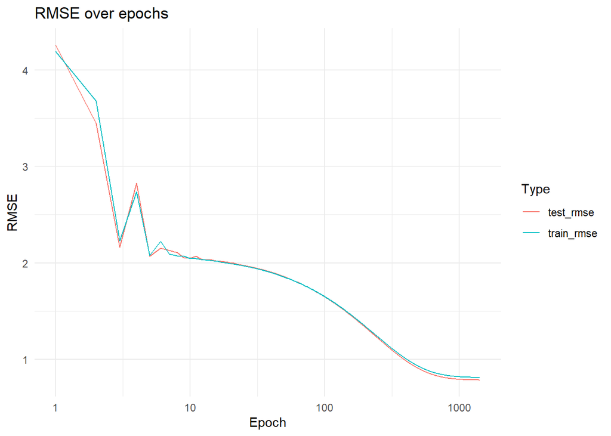

```r
# Plot the RMSE over epochs
log1_df <- tibble(epoch = 1:length(log1$train_rmse), train_rmse = log1$train_rmse, test_rmse = log1$test_rmse)
log1_df <- gather(log1_df, key = "Type", value = "rmse", -epoch)
ggplot(log1_df, aes(x = epoch, y = rmse, color = Type)) +
  geom_line() +
  labs(title = "RMSE over epochs", x = "Epoch", y = "RMSE") +
  theme_minimal() +
  scale_x_log10()
```

### Covariate Shift

```r
summary(wine.red)
```

```
##  fixed.acidity   volatile.acidity  citric.acid    residual.sugar
##  Min.   : 4.60   Min.   :0.1200   Min.   :0.000   Min.   : 0.900
##  1st Qu.: 7.10   1st Qu.:0.3900   1st Qu.:0.090   1st Qu.: 1.900
##  Median : 7.90   Median :0.5200   Median :0.260   Median : 2.200
##  Mean   : 8.32   Mean   :0.5278   Mean   :0.271   Mean   : 2.539
##  3rd Qu.: 9.20   3rd Qu.:0.6400   3rd Qu.:0.420   3rd Qu.: 2.600
##  Max.   :15.90   Max.   :1.5800   Max.   :1.000   Max.   :15.500
##    chlorides       free.sulfur.dioxide total.sulfur.dioxide    density
##  Min.   :0.01200   Min.   : 1.00       Min.   :  6.00       Min.   :0.9901
##  1st Qu.:0.07000   1st Qu.: 7.00       1st Qu.: 22.00       1st Qu.:0.9956
##  Median :0.07900   Median :14.00       Median : 38.00       Median :0.9968
##  Mean   :0.08747   Mean   :15.87       Mean   : 46.47       Mean   :0.9967
##  3rd Qu.:0.09000   3rd Qu.:21.00       3rd Qu.: 62.00       3rd Qu.:0.9978
##  Max.   :0.61100   Max.   :72.00       Max.   :289.00       Max.   :1.0037
##        pH          sulphates         alcohol         quality
##  Min.   :2.740   Min.   :0.3300   Min.   : 8.40   Min.   :3.000
##  1st Qu.:3.210   1st Qu.:0.5500   1st Qu.: 9.50   1st Qu.:5.000
##  Median :3.310   Median :0.6200   Median :10.20   Median :6.000
##  Mean   :3.311   Mean   :0.6581   Mean   :10.42   Mean   :5.636
##  3rd Qu.:3.400   3rd Qu.:0.7300   3rd Qu.:11.10   3rd Qu.:6.000
##  Max.   :4.010   Max.   :2.0000   Max.   :14.90   Max.   :8.000
```

```r
summary(wine.white)
```

```
##  fixed.acidity    volatile.acidity  citric.acid     residual.sugar
##  Min.   : 3.800   Min.   :0.0800   Min.   :0.0000   Min.   : 0.600
##  1st Qu.: 6.300   1st Qu.:0.2100   1st Qu.:0.2700   1st Qu.: 1.700
##  Median : 6.800   Median :0.2600   Median :0.3200   Median : 5.200
##  Mean   : 6.855   Mean   :0.2782   Mean   :0.3342   Mean   : 6.391
##  3rd Qu.: 7.300   3rd Qu.:0.3200   3rd Qu.:0.3900   3rd Qu.: 9.900
##  Max.   :14.200   Max.   :1.1000   Max.   :1.6600   Max.   :65.800
##    chlorides       free.sulfur.dioxide total.sulfur.dioxide    density
##  Min.   :0.00900   Min.   :  2.00      Min.   :  9.0        Min.   :0.9871
##  1st Qu.:0.03600   1st Qu.: 23.00      1st Qu.:108.0        1st Qu.:0.9917
##  Median :0.04300   Median : 34.00      Median :134.0        Median :0.9937
##  Mean   :0.04577   Mean   : 35.31      Mean   :138.4        Mean   :0.9940
##  3rd Qu.:0.05000   3rd Qu.: 46.00      3rd Qu.:167.0        3rd Qu.:0.9961
##  Max.   :0.34600   Max.   :289.00      Max.   :440.0        Max.   :1.0390
##        pH          sulphates         alcohol         quality
##  Min.   :2.720   Min.   :0.2200   Min.   : 8.00   Min.   :3.000
##  1st Qu.:3.090   1st Qu.:0.4100   1st Qu.: 9.50   1st Qu.:5.000
##  Median :3.180   Median :0.4700   Median :10.40   Median :6.000
##  Mean   :3.188   Mean   :0.4898   Mean   :10.51   Mean   :5.878
##  3rd Qu.:3.280   3rd Qu.:0.5500   3rd Qu.:11.40   3rd Qu.:6.000
##  Max.   :3.820   Max.   :1.0800   Max.   :14.20   Max.   :9.000
```

```r
# Check if red wine dataset has the same predictors as the white wine dataset
dim(bake.red)
```

```
## [1] 1599   12
```

```r
# Predict on a new dataset
model_name <- "lm"
preds_red <- predict(lm_fitted, new_data = wine.red)
test_preds <- preds_red |>
  bind_cols(actual = wine.red$quality)
rmse_val <- rmse(test_preds, truth = actual, estimate = .pred) |> pull(.estimate)
mae_val <- mae(test_preds, truth = actual, estimate = .pred) |> pull(.estimate)
tibble(
  model = model_name,
  test_rmse = rmse_val,
  test_mae = mae_val
  )
```

```
## # A tibble: 1 × 3
##   model test_rmse test_mae
##   <chr>     <dbl>    <dbl>
## 1 lm         1.08    0.911
```

Based on the summary statistics provided for the red wine and white wine datasets, we can observe **covariate shift** for certain predictors. Notably, the “residual.sugar” predictor exhibits a significant shift, with the median value being 5.2 in the white wine dataset, compared to only 2.2 in the red wine dataset. The range of values also differs considerably, with the maximum value in the white wine dataset (65.8) being much higher than in the red wine dataset (15.5). Additionally, the “free.sulfur.dioxide” predictor shows a shift in distribution, with the white wine dataset having higher values overall. The median value in the white wine dataset is 34, while in the red wine dataset, it is only 14. The “total.sulfur.dioxide” predictor also demonstrates covariate shift, with the white wine dataset having generally higher values compared to the red wine dataset.

On the contrary, the pH values have similar distributions in both datasets. The median pH value is 3.18 in the white wine dataset and 3.31 in the red wine dataset. The range of pH values is also comparable, with the minimum and maximum values being close in both datasets. The distribution of sulphates is also relatively similar in both datasets. The median value is 0.47 in the white wine dataset and 0.62 in the red wine dataset. The range of values is also comparable.

These differences in the distributions of input variables between the white wine and red wine datasets indicate the presence of covariate shift for the mentioned predictors, but the shift is not to the same degree for all predictors.

### Concept Shift

We then moved to check for concept shift by comparing the test performances of the red wine dataset with the test performances of the white wine dataset. We will also use the same model and hyperparameters as the white wine dataset to predict the red wine dataset.

```r
# Function of evaluating each model by OOD
eval_ood <- function(model, model_name) {
  ood_preds <- predict(model, new_data = wine.red) |>
    bind_cols(actual = wine.red$quality)

  rmse_ood <- rmse(ood_preds, truth = actual, estimate = .pred) |> pull(.estimate)
  mae_ood <- mae(ood_preds, truth = actual, estimate = .pred) |> pull(.estimate)

  tibble(
    model = model_name,
    ood_rmse = rmse_ood,
    ood_mae = mae_ood
  )
}
# lm_baseline model
lm_baseline.ood <- eval_ood(lm_baseline_fitted, "lm_baseline")
# lm model
lm.ood <- eval_ood(lm_fitted, "lm")
# Random forest model
rf.ood <- eval_ood(rf_fitted, "rf")
# Boosted trees model
boost.ood <- eval_ood(boost_fitted, "boost")
# Single tree model
tree.ood <- eval_ood(tree_fitted, "tree")
# Cubist model
cubist.ood <- eval_ood(cubist_fitted, "cubist")
# Elastic net model
enet.ood <- eval_ood(enet_fitted, "enet")
# SVM Model
svm.ood <- eval_ood(svm_fitted, "svm")
# Lasso model
lasso.ood <- eval_ood(lasso_fitted, "lasso")
# MLP model
mlp.ood <- eval_ood(mlp_fitted, "mlp")
```

```
## 50/50 - 0s - 47ms/epoch - 932us/step
```

```r
# SVM model
svm.ood <- eval_ood(svm_fitted, "svm")

# Combined all of the results
ood_results <- bind_rows(lm_baseline.ood, lm.ood, rf.ood, boost.ood, tree.ood, cubist.ood,
                         enet.ood, svm.ood, lasso.ood, mlp.ood, svm.ood)

ood_and_in_distribution_combined <- left_join(results_combined, ood_results, by = "model")

ood_and_in_distribution_combined <- ood_and_in_distribution_combined %>% mutate(ood_rmse/test_rmse)
ood_tibble <- ood_and_in_distribution_combined[!duplicated(ood_and_in_distribution_combined$model), ]
(ood_tibble <- ood_tibble[order(ood_tibble$ood_rmse),] |> mutate(across(where(is.numeric), ~ round(., 3))))
```

```
## # A tibble: 11 × 8
##    model       test_rmse test_mae train_rmse train_mae ood_rmse ood_mae
##    <chr>           <dbl>    <dbl>      <dbl>     <dbl>    <dbl>   <dbl>
##  1 lm_baseline     0.785    0.621      0.791     0.618    0.738   0.591
##  2 mlp             0.737    0.584      0.722     0.574    0.929   0.676
##  3 tree            0.74     0.582      0.689     0.541    0.983   0.703
##  4 rf              0.609    0.446      0.233     0.166    1.01    0.801
##  5 enet            0.749    0.589      0.752     0.583    1.02    0.842
##  6 lasso           0.754    0.591      0.751     0.582    1.03    0.857
##  7 lm              0.755    0.587      0.749     0.583    1.08    0.911
##  8 boost           0.653    0.432      0.002     0.001    1.27    1.06
##  9 cubist          0.656    0.493      0.422     0.311    1.39    1.17
## 10 svm             0.674    0.486      0.149     0.144    2.13    1.75
## 11 gam             0.729    0.579      0.724     0.565   NA      NA
## # ℹ 1 more variable: `ood_rmse/test_rmse` <dbl>
```

In contrast, the “lm_baseline” model, which consists of only three predictors, shows a remarkable improvement in performance when applied to the red wine dataset. Its test RMSE on the white wine dataset is 0.78, while the OOD RMSE on the red wine dataset is 0.74, resulting in a ratio of 0.94. This indicates that the simpler linear model is able to capture the fundamental relationships between the input features and the quality score more effectively, even in the presence of concept shift. The superior generalisation of the “lm_baseline” model suggests that the key predictors included in this model have a more consistent and stable relationship with the quality score across both the white wine and red wine datasets. The model’s simplicity and focus on the most informative features enable it to adapt better to the changes in the underlying CEF.

It is worth noting that the presence of covariate shift, where the distribution of input features differs between the two datasets, can also contribute to the performance degradation of the more complex models. These models may have overfit to the specific characteristics of the white wine dataset, making it challenging for them to generalize well to the red wine dataset.